# Introduction to SoilProfileCollection Objects

# Introduction

This is a basic introduction to the `SoilProfileCollection` class object defined in the `aqp` package for **R**.

The `SoilProfileCollection` class was designed to simplify the process of working with the collection of data associated with soil profiles: site-level data, horizon-level data, spatial data, diagnostic horizon data, metadata, etc.

Examples listed below are meant to be copied/pasted from this document and interactively run within **R**. Comments (preceded by `#` symbol) briefly describe what the code in each line does. Further documentation on objects and functions from the `aqp` package can be accessed by typing `help(aqp)` (or more generally, `?function_name`) at the **R** console.

# Setup

In this tutorial we will use some sample data included with the `aqp` package, based on characterization data from 10 soils sampled on serpentinitic parent material as described in [McGahan et al, 2009](https://acsess.onlinelibrary.wiley.com/doi/10.2136/sssaj2008.0087).

To begin you will load required packages. You may have to first install these if missing:

```r
# install CRAN release + dependencies
install.packages('aqp', dependencies = TRUE)
install.packages('remotes', dependencies = TRUE)

# install latest version from GitHub
remotes::install_github("ncss-tech/aqp", dependencies = FALSE)
```

```r
library(aqp)
library(lattice)
```

```r
# load sample data set, a data.frame object with horizon-level data from 10 profiles
data(sp4)
str(sp4)
```

[output not shown]

```r
# optionally read about it...
# ?sp4

# upgrade to SoilProfileCollection
# 'id' is the name of the column containing the profile ID
# 'top' is the name of the column containing horizon upper boundaries
# 'bottom' is the name of the column containing horizon lower boundaries
depths(sp4) <- id ~ top + bottom

# define "horizon designation" column name for the collection
hzdesgnname(sp4) <- 'name'

# check it out:
class(sp4)
```

```
#> [1] "SoilProfileCollection"
#> attr(,"package")
#> [1] "aqp"
```

```r
print(sp4)
```

```
#> SoilProfileCollection with 10 profiles and 30 horizons
#> profile ID: id  |  horizon ID: hzID
#> Depth range: 16 - 49 cm
#>
#> ----- Horizons (6 / 30 rows  |  10 / 14 columns) -----
#>      id hzID top bottom name   K   Mg  Ca CEC_7 ex_Ca_to_Mg
#>  colusa    1   0      3    A 0.3 25.7 9.0  23.0        0.35
#>  colusa    2   3      8  ABt 0.2 23.7 5.6  21.4        0.23
#>  colusa    3   8     30  Bt1 0.1 23.2 1.9  23.7        0.08
#>  colusa    4  30     42  Bt2 0.1 44.3 0.3  43.0        0.01
#>   glenn    5   0      9    A 0.2 21.9 4.4  18.8        0.20
#>   glenn    6   9     34   Bt 0.3 18.9 4.5  27.5        0.20
#> [... more horizons ...]
#>
#> ----- Sites (6 / 10 rows  |  1 / 1 columns) -----
#>         id
#>     colusa
#>      glenn
#>      kings
#>   mariposa
#>  mendocino
#>       napa
#> [... more sites ...]
#>
#> Spatial Data:
#> [EMPTY]
```

# Object Creation

`SoilProfileCollection` objects are typically created by “promoting” `data.frame` objects (rectangular tables of data) that contain at least three essential columns:

1. an ID column uniquely identifying groups of horizons (e.g. pedons)
2. horizon top boundaries
3. horizon bottom boundaries

The `data.frame` is sorted internally according to the profile ID and horizon top boundary. Formula notation is used to define the columns used to promote a `data.frame` object:

```r
idcolumn ~ hz_top_column + hz_bottom_column
```

## Rapid Templating

Small collections of soil profiles can be described using text “templates” and `quickSPC()`. Templates take the form of:

- `ID:AAA|BBB|CCCCCC`: relative thickness specified by horizon designations, split by “|” symbol
- `ID:A-B-C`: horizons of random thickness specified by horizon designations, split by “-” symbol

The “ID:” prefix is optional, with unique IDs generated by the digest package when omitted.

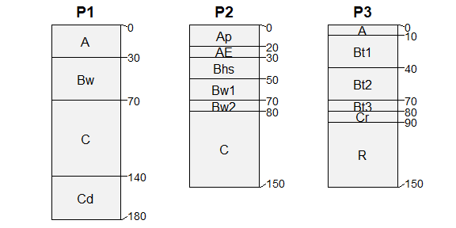

```r
# character vector of horizon templates
# must all use the same formatting
x <- c(
  'P1:AAA|BwBwBwBw|CCCCCCC|CdCdCdCd',
  'P2:ApAp|AE|BhsBhs|Bw1Bw1|Bw2|CCCCCCC',
  'P3:A|Bt1Bt1Bt1|Bt2Bt2Bt2|Bt3|Cr|RRRRRR'
)

# each horizon label is '10' depth-units (default)
s <- quickSPC(x)

# sketch profiles
par(mar = c(0, 0, 0, 0))
plotSPC(s, name.style = 'center-center',
        cex.names = 1, depth.axis = FALSE,
        hz.depths = TRUE
)
```

# Accessing, Setting, and Replacing Data

“Accessor” functions are used to extract specific components from within `SoilProfileCollection` objects.

- Methods that return a column name. These are useful for extracting depths, horizon designations, IDs, etc. before taking an SPC apart for a specific task.
- `idname(sp4)`: extract profile ID name (column name used to init SPC)
- `horizonDepths(sp4)`: horizon top / bottom depth names (used to init SPC)
- `hzidname(sp4)`: horizon ID name (typically automatically built at init time)
- `hzdesgnname(sp4)`: horizon designation name (if set)
- `hztexclname(sp4)`: horizon texture class name (if set)
- Methods that return a vector of values.
- `profile_id(sp4)`: profile IDs, in order
- `hzID(sp4)`: horizon IDs, in order
- `hzDesgn(sp4)`: horizon designations, in order
- Methods that return site/horizon attribute column names.
- `names(sp4)`: site + horizon names concatenated into a single vector
- `horizonNames(sp4)`: horizon names
- `siteNames(sp4)`: site names
- Profile and horizon totals.
- `length(sp4)`: number of profiles in collection
- `nrow(sp4)`: number of horizons in collection
- Other methods.
- `depth_units(sp4)`: defaults to ‘cm’ at SPC creation
- `metadata(sp4)`: returns `list` object with base + optional (user-defined) metadata elements

# Horizon and Site Data

Horizon data and information about key columns (unique profile ID and depths) are the primary input to the methods provided to create the object. Site data can be derived from unique profile-specific values within the input horizon data, or joined in from an external source based on profile ID.

Both site and horizon data are stored as `data.frame` within the SoilProfileCollection; with one or more rows (per profile ID) in the horizon table and one row (per profile ID) in the site table. The SoilProfileCollection also supports `data.table`, or `tibble` objects in the `data.frame` slots.

Columns from site or horizon tables can be accessed with the `$` syntax notation, similar to the `data.frame`. New data can be assigned to either table in the same manner, as long as the length of the new data is:

1. same length as the number of profiles in the collection (target is the site table)
2. same length as the number of horizons in the collection (target is the horizon table)
3. length 1; and selecting the target table requires `site(object)$new_column <- new_value` for new site data and `horizons(object)$new_column <- new value` for horizon

Assignment of new data to existing or new attributes can proceed as follows.

```r
# site-level (based on length of assigned data == number of profiles)
sp4$elevation <- rnorm(n = length(sp4), mean = 1000, sd = 150)

# horizon-level (calculated from two horizon-level columns)
sp4$thickness <- sp4$bottom - sp4$top

# extraction of specific attributes by name
sp4$clay # vector of clay content (horizon data)
```

```
#>  [1] 21 27 32 55 25 34  3 15 27 32 25 31 33 13 21 23 15 17 12 19 14 14 22 25 40 51 67 24 25 32
```

```r
sp4$elevation # vector of simulated elevation (site data)
```

```
#>  [1]  929.0703  948.2966  877.9186 1034.0243  926.2505 1296.0481 1117.5909 1138.3712 1029.2494
#> [10]  826.7750
```

```r
# unit-length value explicitly targeting site data
site(sp4)$collection_id <- 1

# assign a single single value into horizon-level attributes
sp4$constant <- rep(1, times = nrow(sp4))

# unit-length value explicitly targeting horizon data
horizons(sp4)$analysis_group <- "SERP"

# _moves_ the named column from horizon to site
site(sp4) <- ~ constant
```

Horizon and site data can be modified via extraction to `data.frame` followed by replacement (horizon data) or join (site data). Note that while this approach gives the most flexibility, it is also the most dangerous–replacement of horizon data with new data that don’t exactly conform to the original sorting may corrupt your `SoilProfileCollection`.

```r
# extract horizon data to data.frame
h <- horizons(sp4)

# add a new column and save back to original object
h$random.numbers <- rnorm(n = nrow(h), mean = 0, sd = 1)

# _replace_ original horizon data with modified version
replaceHorizons(sp4) <- h

# extract site data to data.frame
s <- site(sp4)

# add a fake group to the site data
s$group <- factor(rep(c('A', 'B'), length.out = nrow(s)))

# join new site data with previous data: old data are _not_ replaced
site(sp4) <- s

# check
sp4
```

```
#> SoilProfileCollection with 10 profiles and 30 horizons
#> profile ID: id  |  horizon ID: hzID
#> Depth range: 16 - 49 cm
#>
#> ----- Horizons (6 / 30 rows  |  10 / 17 columns) -----
#>      id hzID top bottom name   K   Mg  Ca CEC_7 ex_Ca_to_Mg
#>  colusa    1   0      3    A 0.3 25.7 9.0  23.0        0.35
#>  colusa    2   3      8  ABt 0.2 23.7 5.6  21.4        0.23
#>  colusa    3   8     30  Bt1 0.1 23.2 1.9  23.7        0.08
#>  colusa    4  30     42  Bt2 0.1 44.3 0.3  43.0        0.01
#>   glenn    5   0      9    A 0.2 21.9 4.4  18.8        0.20
#>   glenn    6   9     34   Bt 0.3 18.9 4.5  27.5        0.20
#> [... more horizons ...]
#>
#> ----- Sites (6 / 10 rows  |  5 / 5 columns) -----
#>         id elevation collection_id constant group
#>     colusa  929.0703             1        1     A
#>      glenn  948.2966             1        1     B
#>      kings  877.9186             1        1     A
#>   mariposa 1034.0243             1        1     B
#>  mendocino  926.2505             1        1     A
#>       napa 1296.0481             1        1     B
#> [... more sites ...]
#>
#> Spatial Data:
#> [EMPTY]
```

# Diagnostic Horizons

Diagnostic horizons typically span several genetic horizons and may or may not be present in every profile.

To accommodate the wide range of possibilities, diagnostic horizon data are stored as a `data.frame` in “long format”: each row corresponds to a diagnostic feature in a single profile, identified with a column matching the ID column used to initialize the `SoilProfileCollection` object and a label reflecting the feature kind.

For diagnostic horizon data there are no restrictions on data content, as long as each row has an ID that exists within the collection. Be sure to use the ID column name that was used to initialize the SoilProfileCollection object.

```r
dh <- data.frame(
  id = 'colusa',
  kind = 'argillic',
  top = 8,
  bottom = 42,
  stringsAsFactors = FALSE
)

# overwrite any existing diagnostic horizon data
diagnostic_hz(sp4) <- dh

# append to diagnostic horizon data
dh <- diagnostic_hz(sp4)
dh.new <- data.frame(
  id = 'napa',
  kind = 'argillic',
  top = 6,
  bottom = 20,
  stringsAsFactors = FALSE
)

# overwrite existing diagnostic horizon data with appended data
diagnostic_hz(sp4) <- rbind(dh, dh.new)
```

# Root Restrictive Features

Features that restrict root entry (fine or very fine roots) are commonly used to estimate *functional* soil depth. Restrictive features include salt accumulations, duripans, fragipans, paralithic materials, lithic contact, or an abrupt change in chemical property.

Not all soils have restrictive features, therefore these data are stored as a `data.frame` in “long format”. Each row corresponds to a restrictive feature, associated depths, and identified by `profile_id()`. There may be more than one restrictive feature per soil profile.

The example data `sp4` does not describe the restrictive features, so we will simulate some at the bottom of each profile + 20cm.

```r
# get the depth of each profile
rf.top <- profileApply(sp4, max)
rf.bottom <- rf.top + 20

# the profile IDs can be extracted from the names attribute
pIDs <- names(rf.top)

# note: profile IDs must be stored in a column named for idname(sp4) -> 'id'
rf <- data.frame(
  id = pIDs,
  top = rf.top,
  bottom = rf.bottom,
  kind = 'fake',
  stringsAsFactors = FALSE
)

# overwrite any existing diagnostic horizon data
restrictions(sp4) <- rf

# check
restrictions(sp4)
```

```
#>                id top bottom kind
#> 1          colusa  42     62 fake
#> 2           glenn  34     54 fake
#> 3           kings  40     60 fake
#> 4        mariposa  49     69 fake
#> 5       mendocino  30     50 fake
#> 6            napa  20     40 fake
#> 7      san benito  20     40 fake
#> 8          shasta  40     60 fake
#> 9  shasta-trinity  40     60 fake
#> 10         tehama  16     36 fake
```

# Object Metadata

SoilProfileCollection metadata can be extracted and set using the `metadata()` and `metadata<-` methods.

```r
# metadata structure
str(metadata(sp4))
```

```
#> List of 6
#>  $ aqp_df_class    : chr "data.frame"
#>  $ aqp_group_by    : chr ""
#>  $ aqp_hzdesgn     : chr "name"
#>  $ aqp_hztexcl     : chr ""
#>  $ depth_units     : chr "cm"
#>  $ stringsAsFactors: logi FALSE
```

```r
# alter the depth unit metadata attribute
depth_units(sp4) <- 'inches' # units are really 'cm'

# add or replace custom metadata
metadata(sp4)$describer <- 'DGM'
metadata(sp4)$date <- as.Date('2009-01-01')
metadata(sp4)$citation <- 'McGahan, D.G., Southard, R.J, Claassen, V.P. 2009. Plant-Available Calcium Varies Widely in Soils on Serpentinite Landscapes. Soil Sci. Soc. Am. J. 73: 2087-2095.'

# check new values have been added
str(metadata(sp4))
```

```
#> List of 9
#>  $ aqp_df_class    : chr "data.frame"
#>  $ aqp_group_by    : chr ""
#>  $ aqp_hzdesgn     : chr "name"
#>  $ aqp_hztexcl     : chr ""
#>  $ depth_units     : chr "inches"
#>  $ stringsAsFactors: logi FALSE
#>  $ describer       : chr "DGM"
#>  $ date            : Date[1:1], format: "2009-01-01"
#>  $ citation        : chr "McGahan, D.G., Southard, R.J, Claassen, V.P. 2009. Plant-Available Calcium Varies Widely in Soils on Serpentini"| __truncated__
```

```r
# fix depth units, set back to 'cm'
depth_units(sp4) <- 'cm'
```

# Spatial Data

Spatial data and metadata can be stored within a `SoilProfileCollection` object. To initialize a “spatial” SoilProfileCollection, use `initSpatial()<-` method. This allows you to specify which columns contain the geometry and optionally the Coordinate Reference System of those data. The SoilProfileCollection stores two metadata entries: `coordinates` and `crs` which refer to the column names containing geometric data and the CRS, respectively.

```r
# generate some fake coordinates as site level attributes
sp4$x <- rnorm(n = length(sp4), mean = 354000, sd = 100)
sp4$y <- rnorm(n = length(sp4), mean = 4109533, sd = 100)

# initialize spatial coordinates (CRS optional)
initSpatial(sp4, crs = "EPSG:26911") <- ~ x + y

# extract coordinates as matrix
getSpatial(sp4)
```

```
#>              x       y
#>  [1,] 354036.1 4109433
#>  [2,] 354011.4 4109747
#>  [3,] 353968.5 4109542
#>  [4,] 353982.1 4109544
#>  [5,] 353932.4 4109342
#>  [6,] 354055.4 4109499
#>  [7,] 353984.6 4109343
#>  [8,] 354166.7 4109384
#>  [9,] 354006.4 4109352
#> [10,] 353981.6 4109398
```

```r
# get/set spatial reference system using prj()<-
prj(sp4) <- '+proj=utm +zone=11 +datum=NAD83'

# return CRS information
prj(sp4)
```

```
#> [1] "+proj=utm +zone=11 +datum=NAD83"
```

```r
if (requireNamespace("sf", quietly = TRUE)) {
  # extract spatial data + site level attributes in new spatial object
  sp4.sp <- as(sp4, 'SpatialPointsDataFrame')
  sp4.sf <- as(sp4, 'sf')
}
```

# Validity and Horizon Logic

There are several SoilProfileCollection methods defined to identify corrupted objects/bad depth logic and fix them.

Usually an “invalid” or “corrupt” SoilProfileCollection comes from direct modification of the S4 object slot contents (not using standard methods), which can result in omissions or reordering that bypasses internal accounting methods.

Occasionally issues arise from illogical inputs (depths) or collections that are missing data. The latter cases (standard methods produce a corrupt SPC given some “degenerate” input data) are considered “bugs” that should reported on the issue tracker: https://github.com/ncss-tech/aqp/issues

`checkSPC()` returns TRUE for a SoilProfileCollection that contains all slots defined in the class prototype.

```r
checkSPC(sp4)
```

`spc_in_sync()` is used as the validity method for the SoilProfileCollection, it determines if some reordering of the horizon data relative to the unique profile ID / site order has occurred.

```r
spc_in_sync(sp4)
```

```
#>   nSites relativeOrder valid
#> 1   TRUE          TRUE  TRUE
```

`rebuildSPC()` is used to re-construct all the required slots of a SoilProfileCollection, given a source, possibly corrupt, object. This function fixes major issues related to the internal ordering of data in slots, as well as missing slots or metadata.

```r
z <- rebuildSPC(sp4)
```

`checkHzDepthLogic()` has the ability to perform logical tests on whole profiles or individual horizons. Four different tests are performed related to four common errors in horizon depths:

- bottom depth shallower than top depth
- equal top and bottom depth
- missing (`NA`) top or bottom depth
- gap or overlap between adjacent horizons

```r
checkHzDepthLogic(sp4)
```

```
#>                id valid depthLogic sameDepth missingDepth overlapOrGap
#> 1          colusa  TRUE      FALSE     FALSE        FALSE        FALSE
#> 2           glenn  TRUE      FALSE     FALSE        FALSE        FALSE
#> 3           kings  TRUE      FALSE     FALSE        FALSE        FALSE
#> 4        mariposa  TRUE      FALSE     FALSE        FALSE        FALSE
#> 5       mendocino  TRUE      FALSE     FALSE        FALSE        FALSE
#> 6            napa  TRUE      FALSE     FALSE        FALSE        FALSE
#> 7      san benito  TRUE      FALSE     FALSE        FALSE        FALSE
#> 8          shasta  TRUE      FALSE     FALSE        FALSE        FALSE
#> 9  shasta-trinity  TRUE      FALSE     FALSE        FALSE        FALSE
#> 10         tehama  TRUE      FALSE     FALSE        FALSE        FALSE
```

```r
checkHzDepthLogic(sp4, byhz = TRUE)
```

```
#>                id top bottom valid hzID depthLogic sameDepth missingDepth overlapOrGap
#> 1          colusa   0      3  TRUE    1      FALSE     FALSE        FALSE           NA
#> 2          colusa   3      8  TRUE    2      FALSE     FALSE        FALSE           NA
#> 3          colusa   8     30  TRUE    3      FALSE     FALSE        FALSE           NA
#> 4          colusa  30     42  TRUE    4      FALSE     FALSE        FALSE           NA
#> 5           glenn   0      9  TRUE    5      FALSE     FALSE        FALSE           NA
#> 6           glenn   9     34  TRUE    6      FALSE     FALSE        FALSE           NA
#> 7           kings   0      4  TRUE    7      FALSE     FALSE        FALSE           NA
#> 8           kings   4     13  TRUE    8      FALSE     FALSE        FALSE           NA
#> 9           kings  13     40  TRUE    9      FALSE     FALSE        FALSE           NA
#> 10       mariposa   0      3  TRUE   10      FALSE     FALSE        FALSE           NA
#> 11       mariposa   3     14  TRUE   11      FALSE     FALSE        FALSE           NA
#> 12       mariposa  14     34  TRUE   12      FALSE     FALSE        FALSE           NA
#> 13       mariposa  34     49  TRUE   13      FALSE     FALSE        FALSE           NA
#> 14      mendocino   0      2  TRUE   14      FALSE     FALSE        FALSE           NA
```

[output cut: 16 more lines]

# Coercion

SoilProfileCollection objects can be coerced to `data.frame`, `list` and `SpatialPointsDataFrame` (when spatial slot has been set up):

```r
# check our work by viewing the internal structure
str(sp4)

# create a data.frame from horizon+site data
as(sp4, 'data.frame')

# or, equivalently:
as.data.frame(sp4)

# convert SoilProfileCollection to a named list containing all slots
as(sp4, 'list')

# extraction of site + spatial data as SpatialPointsDataFrame
as(sp4, 'SpatialPointsDataFrame')
```

# Subsetting SoilProfileCollection Objects

`SoilProfileCollection` objects can be subset using the familiar `[`-style notation used by matrix and `data.frame` objects, such that: `spc[i, j]` will return profiles identified by the integer vector `i`, and horizons identified by the integer vector `j`.

Omitting either index will result in all profiles (`i` omitted) or all horizons (`j` omitted).

Typically, site-level attributes will be used as the subsetting criteria. Functions that return an index to matches (such as `grep()` or `which()`) provide the link between attributes and an index to matching profiles.

## Profiles

Using the *i* index, select one or more profiles by numeric index. An index greater than the number of profiles will return an empty `SoilProfileCollection` object.

```r
# explicit string matching
idx <- which(sp4$group == 'A')

# numerical expressions
idx <- which(sp4$elevation < 1000)

# regular expression, matches any profile ID containing 'shasta'
idx <- grep('shasta', profile_id(sp4), ignore.case = TRUE)

# perform subset based on index
sp4[idx, ]
```

In an interactive session, it is often simpler to use `subset()` directly:

```r
subset(sp4, group == 'A')
subset(sp4, elevation < 1000)
subset(sp4, grepl('shasta', id, ignore.case = TRUE))
```

## Horizons by Index

Using the *j* index, select the 2nd horizon from each profile in the collection. Use with caution, asking for a horizon beyond the length of any profile in the collection will result in an error.

```r
sp4[, 2]
```

## Horizons by Keyword

Using the *k* index, select the `.FIRST` first or `.LAST` horizons (by profile) within a collection. Note that `.FIRST` and `.LAST` are special keywords used by the `SoilProfileCollection` subset methods.

```r
sp4[, , .FIRST]
sp4[, , .LAST]
```

Additional *k* index keywords include: `.HZID`, `.NHZ`, `.BOTTOM`, `.TOP`. These can be chained together to get the “top depth of the first horizons” or “row-index (horizon data) of the last horizons”:

```r
sp4[, , .FIRST, .TOP]
sp4[, , .LAST, .HZID]
```

# Splitting, Duplication, and Selection of Unique Profiles

`SoilProfileCollection` objects are combined by passing a list of objects to the `combine()` function.

Ideally all objects share the same internal structure, profile ID, horizon ID, depth units, and other parameters of a `SoilProfileCollection`. Manually subset the example data into 3 pieces, compile into a list, and then `combine` back together.

```r
# subset data into chunks
s1 <- sp4[1:2, ]
s2 <- sp4[4, ]
s3 <- sp4[c(6, 8, 9), ]

# combine subsets
s <- combine(list(s1, s2, s3))

# double-check result
plotSPC(s)
```

It is possible to combine `SoilProfileCollection` objects with different internal structure. The final object will contain the all site and horizon columns from the inputs, possibly creating sparse tables. IDs and horizon depth names are taken from the first object.

```r
# sample data as data.frame objects
data(sp1)
data(sp3)

# rename IDs horizon top / bottom columns
sp3$newid <- sp3$id
sp3$hztop <- sp3$top
sp3$hzbottom <- sp3$bottom

# remove originals
sp3$id <- NULL
sp3$top <- NULL
sp3$bottom <- NULL

# promote to SoilProfileCollection
depths(sp1) <- id ~ top + bottom
depths(sp3) <- newid ~ hztop + hzbottom

# label each group via site-level attribute
site(sp1)$g <- 'sp1'
site(sp3)$g <- 'sp3'

# combine
x <- combine(list(sp1, sp3))

# make grouping variable into a factor for groupedProfilePlot
x$g <- factor(x$g)

# check results
str(x)

# graphical check
# convert character horizon IDs into numeric
x$.horizon_ids_numeric <- as.numeric(hzID(x))

par(mar = c(0, 0, 3, 1))
plotSPC(x, color='.horizon_ids_numeric', col.label = 'Horizon ID')
groupedProfilePlot(x, 'g', color='.horizon_ids_numeric', col.label = 'Horizon ID', group.name.offset = -15)
```

## Splitting

The inverse of `combine()` is `split()`: subsets of the `SoilProfileCollection` are split into list elements, each containing a new `SoilProfileCollection`.

```r
# continuing from above
# split subsets of x into a list of SoilProfileCollection objects using site-level attribute 'g'
res <- split(x, 'g')
str(res, 1)
```

## Duplication

Duplicate the first profile in `sp4` (Colusa) 8 times, resulting in a new `SoilProfileCollection` object containing unique profile IDs.

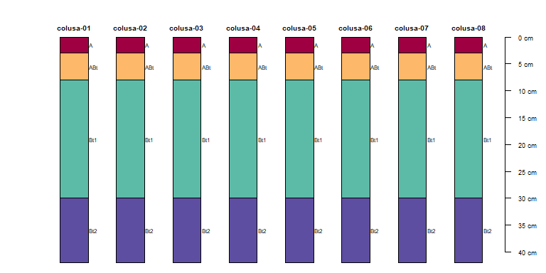

```r
d <- duplicate(sp4[1, ], times = 8)
par(mar = c(0, 2, 0, 1))
plotSPC(d, color = 'ex_Ca_to_Mg')
```

## Selecting Unique Profiles

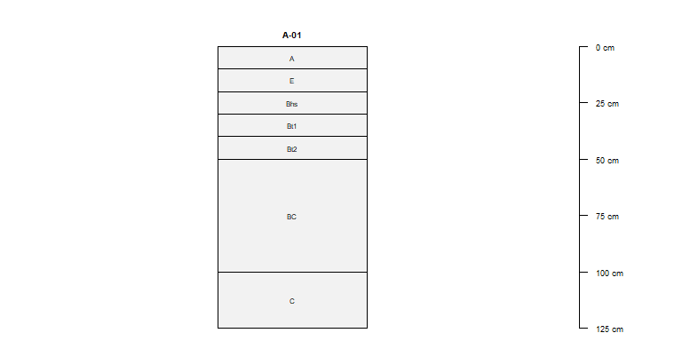

```r
# an example soil profile
x <- data.frame(
  id = 'A',
  name = c('A', 'E', 'Bhs', 'Bt1', 'Bt2', 'BC', 'C'),
  top = c(0, 10, 20, 30, 40, 50, 100),
  bottom = c(10, 20, 30, 40, 50, 100, 125),
  z = c(8, 5, 3, 7, 10, 2, 12)
)

# init SPC
depths(x) <- id ~ top + bottom
hzdesgnname(x) <- 'name'

# horizon depth variability for simulation
horizons(x)$.sd <- 2

# duplicate several times
x.dupes <- duplicate(x, times = 5)

# simulate some new profiles based on example
# 2cm constant standard deviation of transition between horizons assumed
x.sim <- perturb(x, n = 5, thickness.attr = '.sd')

# graphical check
par(mar = c(0, 2, 0, 4))

# inspect unique results
plotSPC(unique(x.dupes, vars = c('top', 'bottom')),
        name.style = 'center-center',
        width = 0.15)
```

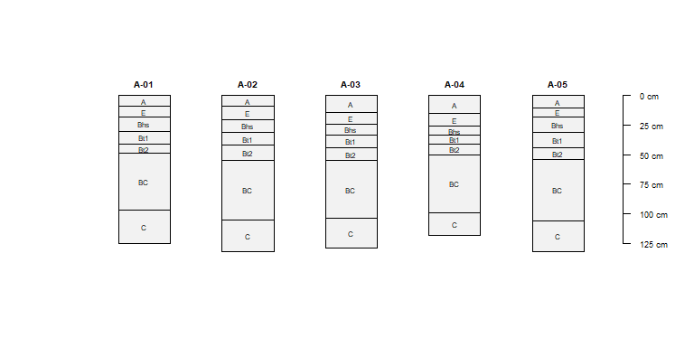

```r
# "uniqueness" is a function of variables selected to consider
plotSPC(unique(x.sim, vars = c('top', 'bottom')),
        name.style = 'center-center')
```

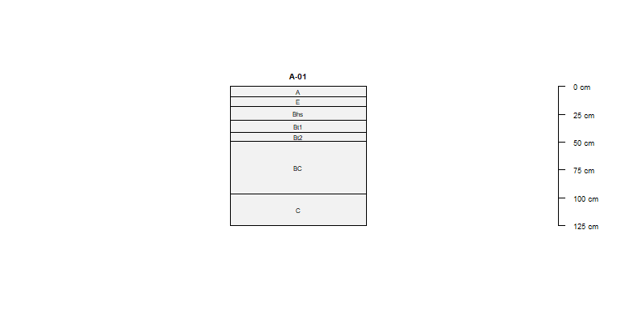

```r
plotSPC(unique(x.sim, vars = c('name')),
        name.style = 'center-center',
        width = 0.15)
```

# Plotting SoilProfileCollection Objects

The `plotSPC()` method for `SoilProfileCollection` objects generates sketches of profiles within the collection based on horizon boundaries, vertically aligned to an integer sequence from 1 to the number of profiles.

Horizon names are automatically extracted from a horizon-level attribute `name` (if present), or via an alternate attributed given as an argument: `name='column.name'`.

Horizon colors are automatically generated from the horizon-level attribute `soil_color`, or any other attribute of **R**-compatible color description given as an argument: `color='column.name'`. This function is highly customizable, therefore, it is prudent to consult `help(plotSPC)` from time to time. Soil colors in Munsell notation can be converted to **R**-compatible colors via `munsell2rgb()`.

Many of the following examples make use of `par()` to set graphical options such as `mar` (customized margins) and/or `xpd = NA` (turn off clipping) to optimize display of different numbers of profiles and various `plotSPC()` arguments.

A detailed description of each argument to `plotSPC()` (and many examples) can be found in the [Soil Profile Sketches tutorial](https://ncss-tech.github.io/AQP/aqp/sketches.html).

## Making Adjustments

The `explainPlotSPC()` function is helpful for adjusting some of the more obscure arguments to `plotSPC()`.

A basic plot with debugging information overlaid:

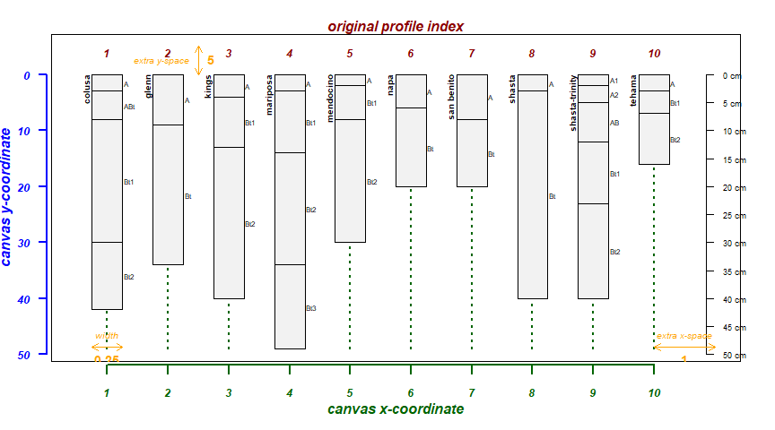

```r
par(mar = c(4, 3, 2, 2))
explainPlotSPC(sp4, name = 'name')
```

Make sketches wider:

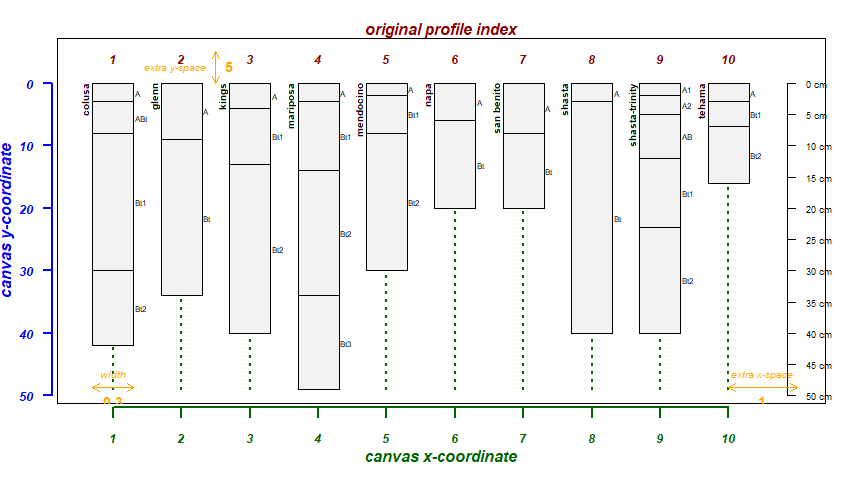

```r
par(mar = c(4, 3, 2, 2))
explainPlotSPC(sp4, name = 'name', width = 0.3)
```

Move soil surface at 0cm “down” 5cm:

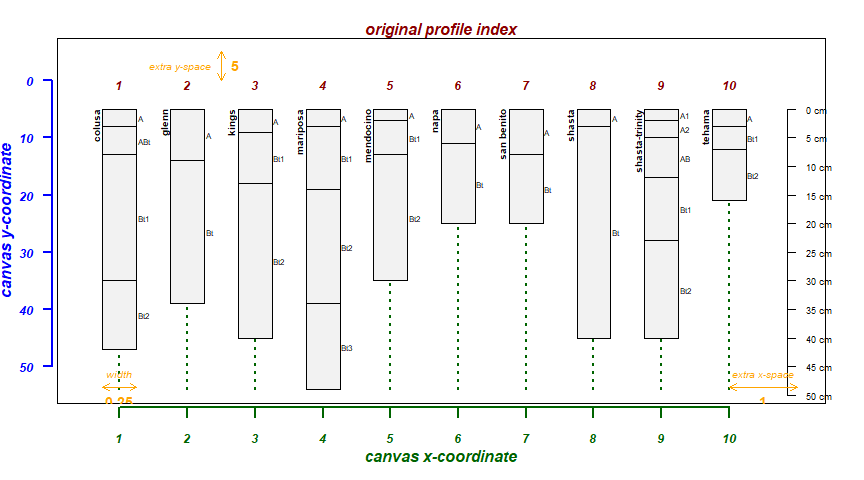

```r
par(mar = c(4, 3, 2, 2))
explainPlotSPC(sp4, name = 'name', y.offset = 5)
```

Move soil surface at 0cm “up” 10cm; useful for sketches of shallow profiles:

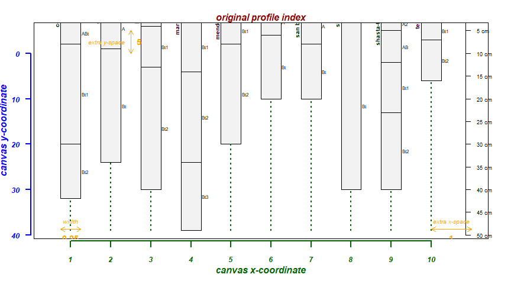

```r
par(mar = c(4, 3, 2, 2))
explainPlotSPC(sp4, name = 'name', y.offset = -10)
```

Scale depths by 50%:

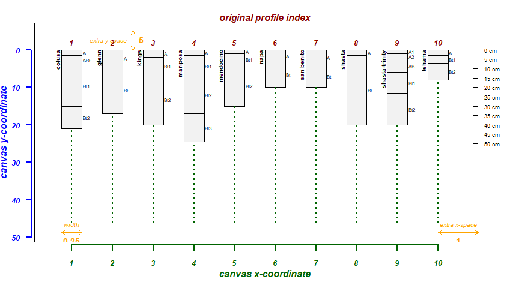

```r
par(mar = c(4, 3, 2, 2))
explainPlotSPC(sp4, name = 'name', scaling.factor = 0.5)
```

A graphical explanation of how profiles are re-arranged via `plot.order` argument:

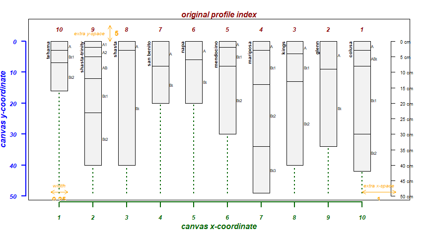

```r
par(mar = c(4, 3, 2, 2))
explainPlotSPC(sp4, name = 'name', plot.order = length(sp4):1)
```

Leave room for an additional 2 profile sketches:

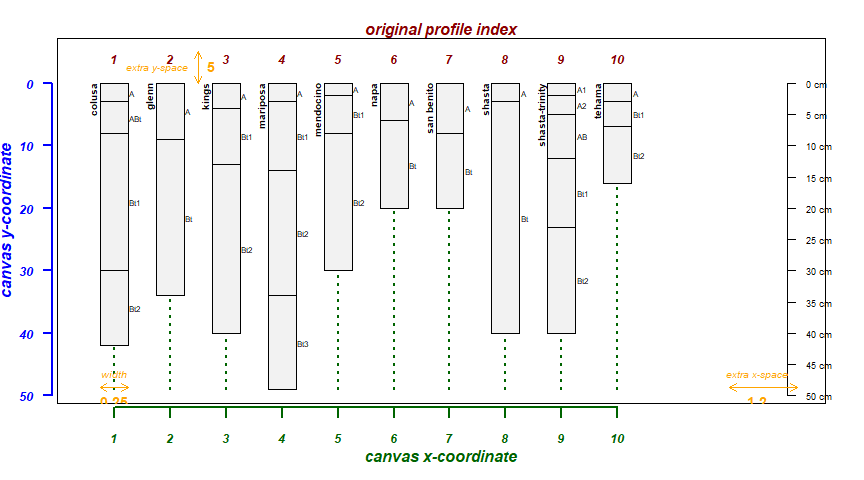

```r
par(mar = c(4, 3, 2, 2))
explainPlotSPC(sp4, name = 'name', n = length(sp4) + 2)
```

### Small SoilProfileCollections

Making quality figures with fewer than 5 soil profiles usually requires more customization of the basic call to `plotSPC`. In general, the following are a good starting point:

- shrink margins and disable clipping with `par`
- adjust output graphic device (e.g. `png()`) dimensions and resolution
- increase font size with `cex.names`
- adjust sketch width with `width`, typically within 0.15-0.35
- move depth axis to the left using negative `line` values, e.g. (`depth.axis = list(line = -2)`)

Get some example data from the Official Series Descriptions:

```r
data(osd)
x <- osd
```

Using 5x6 inch output device:

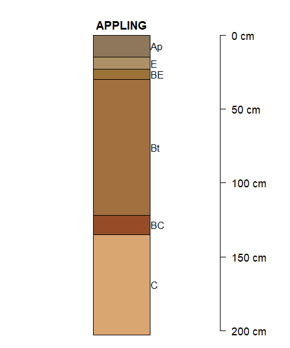

```r
par(mar = c(0, 2, 0, 4), xpd = NA)
plotSPC(x[1, ], cex.names = 1)
```

Using 7x6 inch output device, slight adjustments to `width` usually required:

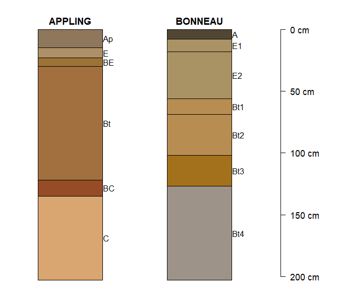

```r
# set margins and turn off clipping
par(mar = c(0, 2, 0, 4), xpd = NA)
plotSPC(x[1:2, ], cex.names = 1, width = 0.25)
```

Using 8x6 inch output device, slight adjustments to are usually required:

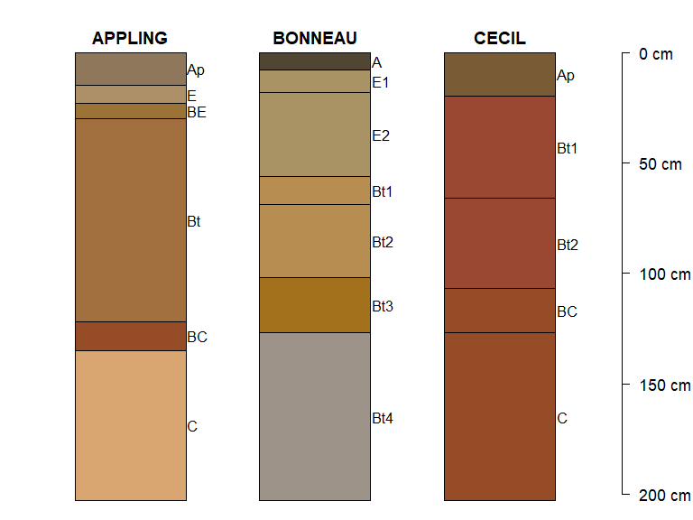

```r
par(mar = c(0, 2, 0, 4), xpd = NA)
plotSPC(x, cex.names = 1, depth.axis = list(line = -0.1), width = 0.3)
```

## Horizon Depth Labeling

Horizon depths can be labeled for each profile as an alternative to a single depth axis.

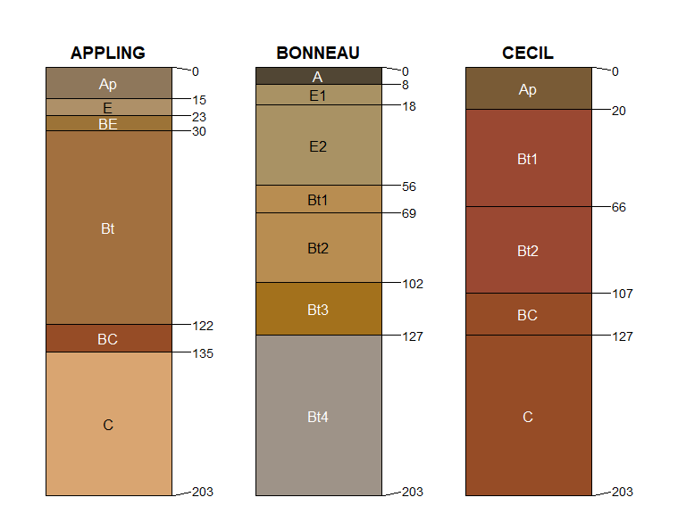

```r
par(mar = c(0, 0, 1, 1))
plotSPC(
  x,
  cex.names = 1,
  name.style = 'center-center',
  width = 0.3,
  depth.axis = FALSE,
  hz.depths = TRUE,
  hz.depths.offset = 0.08
)
```

As of aqp version 1.41, it is possible to “fix” overlapping horizon depth labels with the new `fixLabelCollisions` argument. This approach to labeling depths works best when moving horizon designations with the `name.style` argument. Note that setting `fixLabelCollisions = TRUE` may incur a performance penalty when plotting large `SoilProfileCollection` objects.

As of aqp version 2.0, `fixLabelCollisions` is set to `TRUE` when setting `hz.depths = TRUE`.

## Relative Horizontal Positioning

Relative horizontal positioning via `relative.pos` argument. Can be used with `plot.order` but be careful: `relative.pos` must be specified in the *final* ordering of profiles. See `?plotSPC` for details.

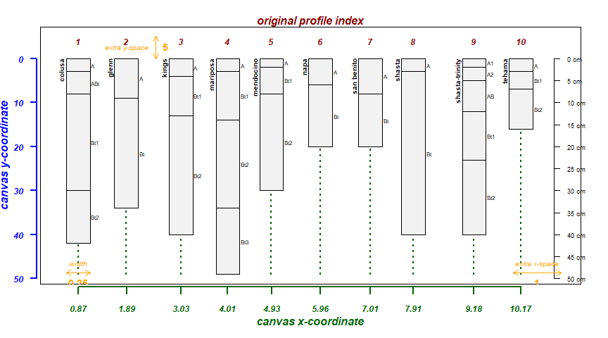

```r
par(mar = c(4, 3, 2, 2))
pos <- jitter(1:length(sp4))
explainPlotSPC(sp4, name = 'name', relative.pos = pos)
```

Relative positioning works well when the vector of positions is close to the default spacing along an integer sequence, but not when positions are closer than the width of a profile sketch.

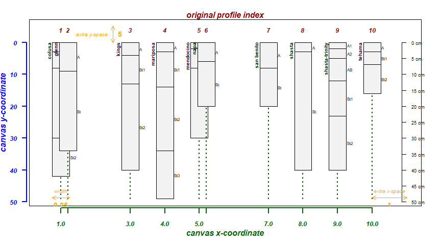

```r
par(mar = c(4, 3, 2, 2))
pos <- c(1, 1.2, 3, 4, 5, 5.2, 7, 8, 9, 10)
explainPlotSPC(sp4, name = 'name', relative.pos = pos)
```

The `fixOverlap()` function can be used to find a suitable arrangement of profiles based on a compromise between the suggested relative positions and minimization of overlap.

This is an iterative procedure, based on random perturbations of overlapping profiles, therefore it is possible for the algorithm to stop at a sub-optimal configuration. Results can be controlled using `set.seed()`.

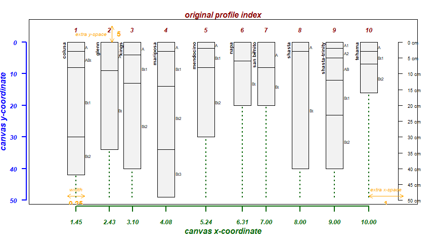

```r
par(mar = c(4, 3, 2, 2))
new.pos <- fixOverlap(pos)
explainPlotSPC(sp4, name = 'name', relative.pos = new.pos)
```

There are several parameters available for optimizing horizontal position in the presence of overlap. See `?fixOverlap` for details and further examples.

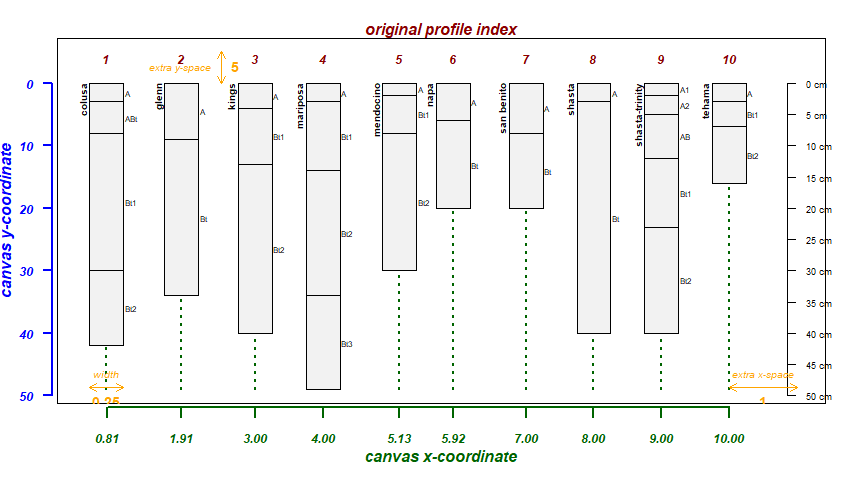

```r
par(mar = c(4, 3, 2, 2))
new.pos <- fixOverlap(pos, thresh = 0.7)
explainPlotSPC(sp4, name = 'name', relative.pos = new.pos)
```

The [SPC plotting ideas tutorial](http://ncss-tech.github.io/AQP/aqp/SPC-plotting-ideas.html) contains several additional examples.

## Thematic Sketches

Horizon-level attributes can be symbolized with color, in this case using the horizon-level attribute “clay”:

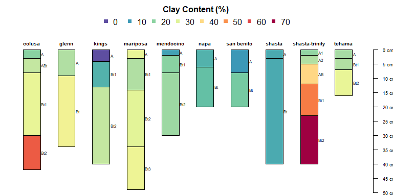

```r
par(mar = c(0, 0, 3, 0))
plotSPC(sp4,
        name = 'name',
        color = 'clay',
        col.label = 'Clay Content (%)')
```

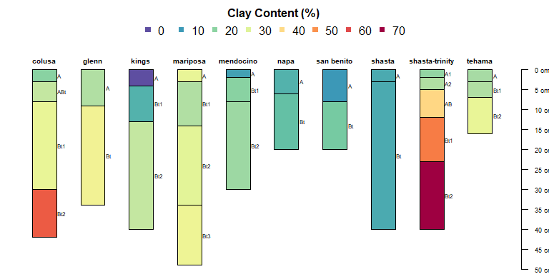

```r
par(mar = c(0, 0, 3, 0))
plotSPC(
  sp4,
  name = 'name',
  color = 'clay',
  col.label = 'Clay Content (%)'
)
```

Categorical properties can also be used to make a thematic sketch. Colors are interpolated when there are more classes than colors provided by `col.palette`:

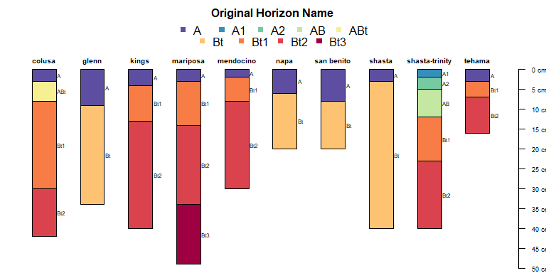

```r
par(mar = c(0, 0, 3, 0))
plotSPC(
  sp4,
  name = 'name',
  color = 'name',
  col.label = 'Original Horizon Name'
)
```

Try with [generalized horizon labels](http://ncss-tech.github.io/AQP/aqp/gen-hz-assignment.html):

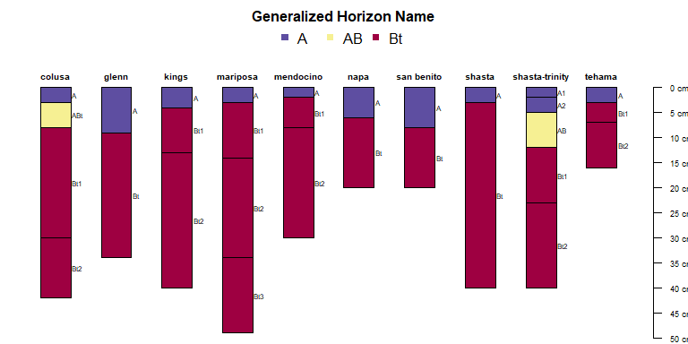

```r
par(mar = c(0, 0, 3, 0))

# generalize horizon names into 3 groups
sp4$genhz <- generalize.hz(sp4$name, new = c('A', 'AB', 'Bt'), pat = c('A[0-9]?', 'AB', '^Bt'))

plotSPC(
  sp4,
  name = 'name',
  color = 'genhz',
  col.label = 'Generalized Horizon Name'
)
```

Horizon-level attributes that represent a volume fraction (e.g. coarse-fragment percentage) can be added to an existing figure. See `?addVolumeFraction` for adding layers to an existing plot based on these attributes.

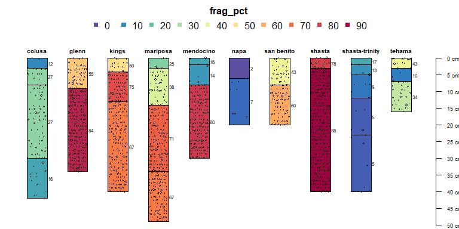

```r
par(mar = c(0, 0, 3, 0))
# convert coarse rock fragment proportion to percentage
sp4$frag_pct <- sp4$CF * 100

# label horizons with fragment percent
plotSPC(sp4, name = 'frag_pct', color = 'frag_pct')

# symbolize volume fraction data
addVolumeFraction(sp4, colname = 'frag_pct')
```

## Depth Intervals

Annotation of depth-intervals can be accomplished using “brackets”. Here we extract top/bottom depths associated with top and bottom depth A horizons using the min/max variants of the `depthOf()` function. See ?depthOf for more details.

```r
# extract top/bottom depths associated with all A horizons
tops <- minDepthOf(sp4, pattern = '^A', hzdesgn = 'name', top = TRUE)
bottoms <- maxDepthOf(sp4, pattern = '^A', hzdesgn = 'name', top = FALSE)

IDs <- profile_id(sp4)

# assemble data.frame
a <- data.frame(id = IDs, top = tops$top, bottom = bottoms$bottom)

# check
a
```

```
#>                id top bottom
#> 1          colusa   0      8
#> 2           glenn   0      9
#> 3           kings   0      4
#> 4        mariposa   0      3
#> 5       mendocino   0      2
#> 6            napa   0      6
#> 7      san benito   0      8
#> 8          shasta   0      3
#> 9  shasta-trinity   0     12
#> 10         tehama   0      3
```

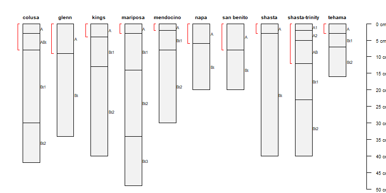

```r
par(mar = c(0, 0, 0, 0))
plotSPC(sp4)

# annotate A horizon depth interval with brackets
addBracket(a, col = 'red', offset = -0.4)
```

Add labels:

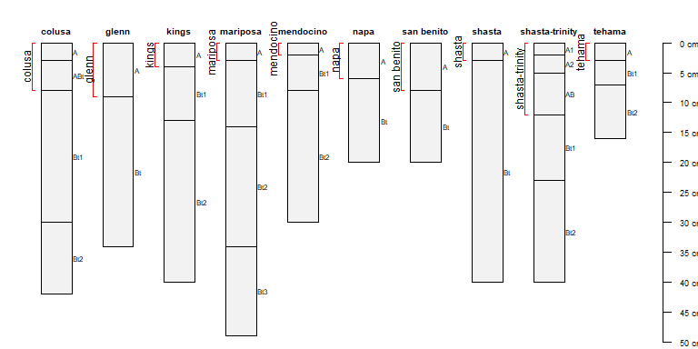

```r
par(mar = c(0, 0, 0, 0))
plotSPC(sp4, name = 'name')

# label
a$label <- site(sp4)$id

# note that depth brackets "know which profiles to use" via profile ID
addBracket(
  a,
  labcol = 'label',
  col = 'red',
  label.cex = 0.75,
  missing.bottom.depth = 25,
  offset = -0.4
)
```

It is possible to arrange profile sketches by site-level grouping variable:

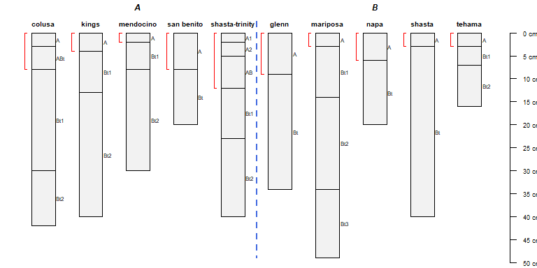

```r
par(mar = c(0, 0, 0, 0))
groupedProfilePlot(sp4, groups = 'group')
addBracket(a, col = 'red', offset = -0.4)
```

There need not be brackets for all profiles in a collection:

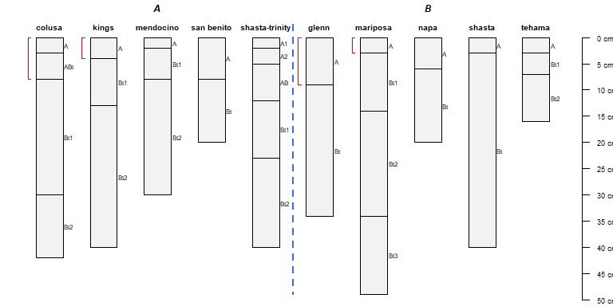

```r
par(mar = c(0, 0, 0, 0))
a.sub <- a[1:4,]
groupedProfilePlot(sp4, groups = 'group')
addBracket(a.sub, col = 'red', offset = -0.4)
```

When bottom depths are missing an arrow is used:

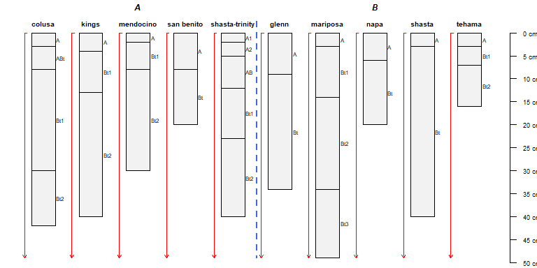

```r
a$bottom <- NA
par(mar = c(0, 0, 0, 0))
groupedProfilePlot(sp4, groups = 'group')
addBracket(a, col = 'red', offset = -0.4)
```

Manually define bottom depth:

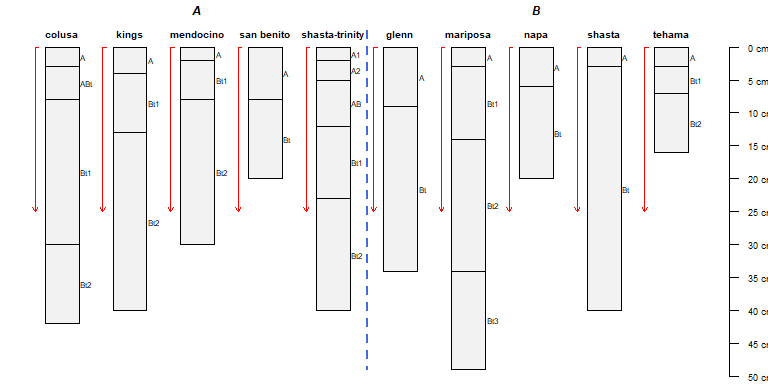

```r
par(mar = c(0, 0, 0, 0))
groupedProfilePlot(sp4, groups = 'group')
addBracket(
  a,
  col = 'red',
  label.cex = 0.75,
  missing.bottom.depth = 25,
  offset = -0.4
)
```

Further customization of brackets:

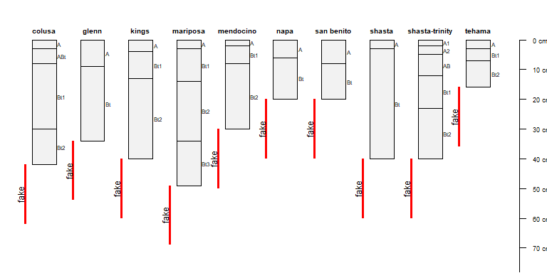

```r
par(mar = c(0, 0, 0, 0))
plotSPC(sp4, max.depth = 75)

# copy root-restricting features
a <- restrictions(sp4)

# add a label: restrictive feature 'kind'
a$label <- a$kind

# add restrictions using vertical bars
addBracket(
  a,
  labcol = 'label',
  col = 'red',
  label.cex = 0.75,
  tick.length = 0,
  lwd = 3,
  offset = -0.4
)
```

### Notes

These functions (`addBracket()`, `addDiagnosticBracket()`, and `addVolumeFraction()`) will automatically compensate for alternative sketch ordering or relative positioning of profiles.